# Exploration

Nicholas Mallis

10/11/2021

### Data Loading and Cleaning

```r
#load needed packages. make sure they are installed.
library(ggplot2) #for plotting
library(broom) #for cleaning up output from lm()
library(here) #for data loading/saving
library(tidyverse)
#path to data
#note the use of the here() package and not absolute paths
data_location <- here::here("data","processed_data","processeddata.rds")

#load data.
mydata <- readRDS(data_location)

glimpse(mydata)
```

```
## Rows: 730
## Columns: 32
## $ SwollenLymphNodes <fct> Yes, Yes, Yes, Yes, Yes, No, No, No, Yes, No, Yes, Y…
## $ ChestCongestion   <fct> No, Yes, Yes, Yes, No, No, No, Yes, Yes, Yes, Yes, Y…
## $ ChillsSweats      <fct> No, No, Yes, Yes, Yes, Yes, Yes, Yes, Yes, No, Yes, …
## $ NasalCongestion   <fct> No, Yes, Yes, Yes, No, No, No, Yes, Yes, Yes, Yes, Y…
## $ CoughYN           <fct> Yes, Yes, No, Yes, No, Yes, Yes, Yes, Yes, Yes, No, …
## $ Sneeze            <fct> No, No, Yes, Yes, No, Yes, No, Yes, No, No, No, No, …
## $ Fatigue           <fct> Yes, Yes, Yes, Yes, Yes, Yes, Yes, Yes, Yes, Yes, Ye…
## $ SubjectiveFever   <fct> Yes, Yes, Yes, Yes, Yes, Yes, Yes, Yes, Yes, No, Yes…
## $ Headache          <fct> Yes, Yes, Yes, Yes, Yes, Yes, No, Yes, Yes, Yes, Yes…
## $ Weakness          <fct> Mild, Severe, Severe, Severe, Moderate, Moderate, Mi…
## $ WeaknessYN        <fct> Yes, Yes, Yes, Yes, Yes, Yes, Yes, Yes, Yes, Yes, Ye…
## $ CoughIntensity    <fct> Severe, Severe, Mild, Moderate, None, Moderate, Seve…
## $ CoughYN2          <fct> Yes, Yes, Yes, Yes, No, Yes, Yes, Yes, Yes, Yes, Yes…
```

[output cut: 19 more lines]

Descriptive Statistics: Tabling the Main Outcome(s) and Covariates using the table1 package

|  | Total (N=730) |
| --- | --- |
| Nausea |  |
| No | 475 (65.1%) |
| Yes | 255 (34.9%) |
| BodyTemp |  |
| Mean (SD) | 98.9 (1.20) |
| Median [Min, Max] | 98.5 [97.2, 103] |
| RunnyNose |  |
| No | 211 (28.9%) |
| Yes | 519 (71.1%) |
| SwollenLymphNodes |  |
| No | 418 (57.3%) |
| Yes | 312 (42.7%) |
| ChestCongestion |  |
| No | 323 (44.2%) |
| Yes | 407 (55.8%) |
| Weakness |  |
| None | 49 (6.7%) |
| Mild | 223 (30.5%) |
| Moderate | 338 (46.3%) |
| Severe | 120 (16.4%) |
| NasalCongestion |  |
| No | 167 (22.9%) |
| Yes | 563 (77.1%) |
| CoughYN |  |
| No | 75 (10.3%) |
| Yes | 655 (89.7%) |
| Sneeze |  |
| No | 339 (46.4%) |
| Yes | 391 (53.6%) |
| Fatigue |  |
| No | 64 (8.8%) |
| Yes | 666 (91.2%) |
| SubjectiveFever |  |
| No | 230 (31.5%) |
| Yes | 500 (68.5%) |
| Headache |  |
| No | 115 (15.8%) |
| Yes | 615 (84.2%) |

### Plotting Nausea

Here we see that 255 (34.9%) of participants reported nausea.

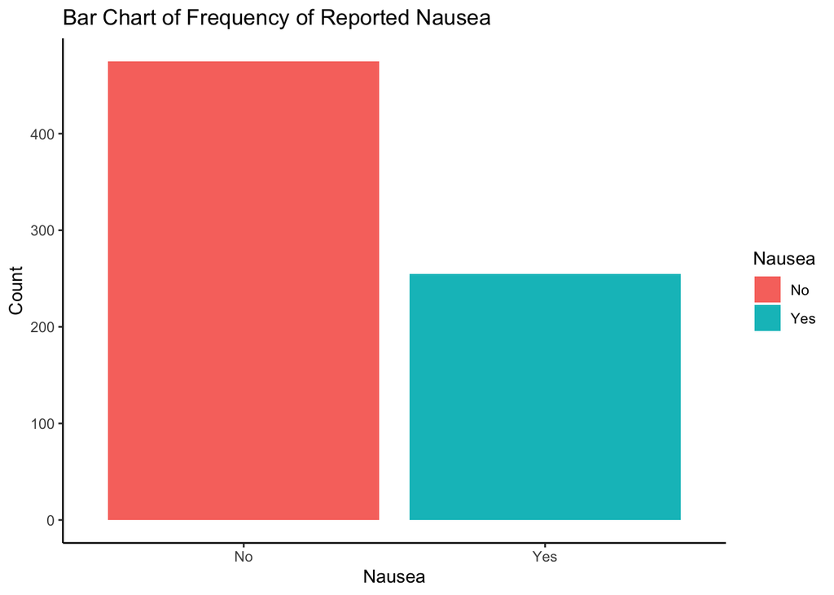

### Plotting Temperature

The median body temperature was 98.5 with a minimum of 97.2 and a maximum of 103. Based on the histogram below, we see that the data seems to be skewed with a tail to the right.

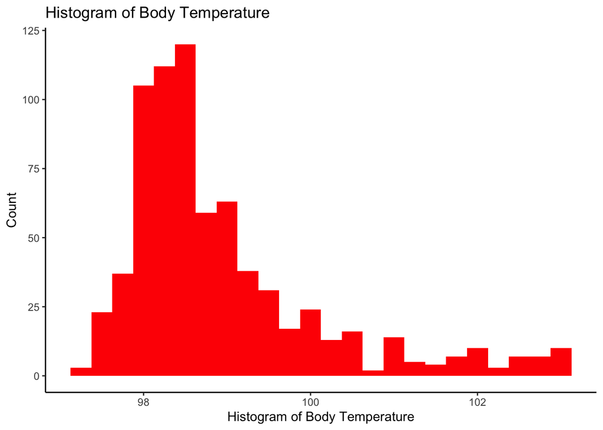

### Plotting Runny Nose

Here we see that 519 (71.1%) of participants reported experiecing a runny nose.

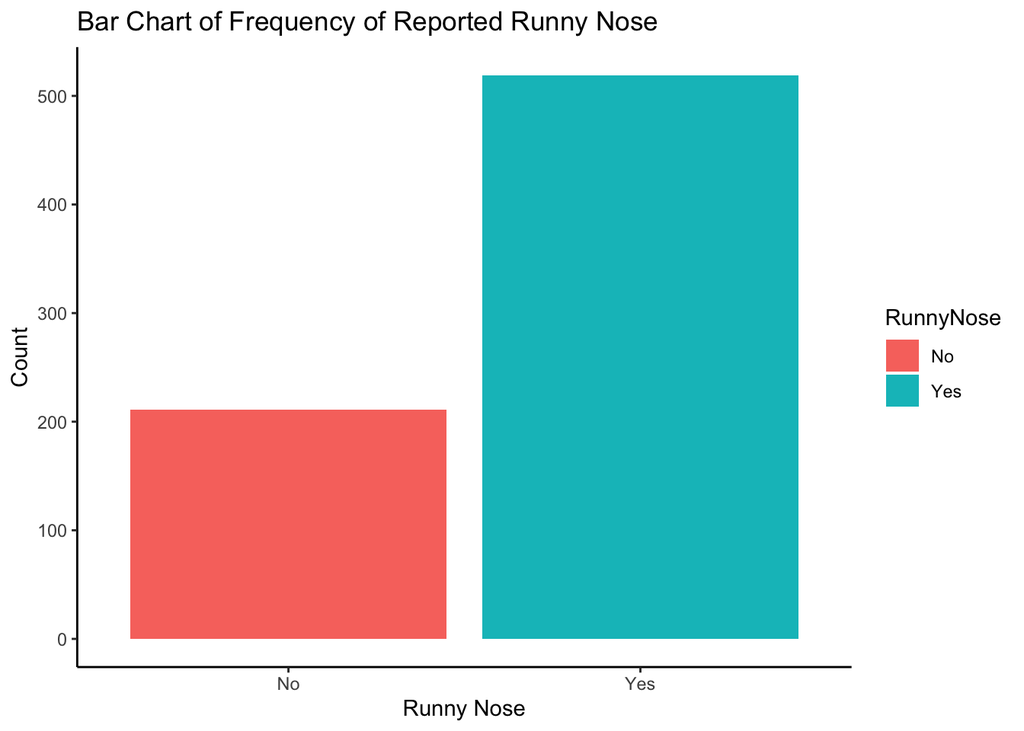

### Plotting Body Temperature vs Runny Nose

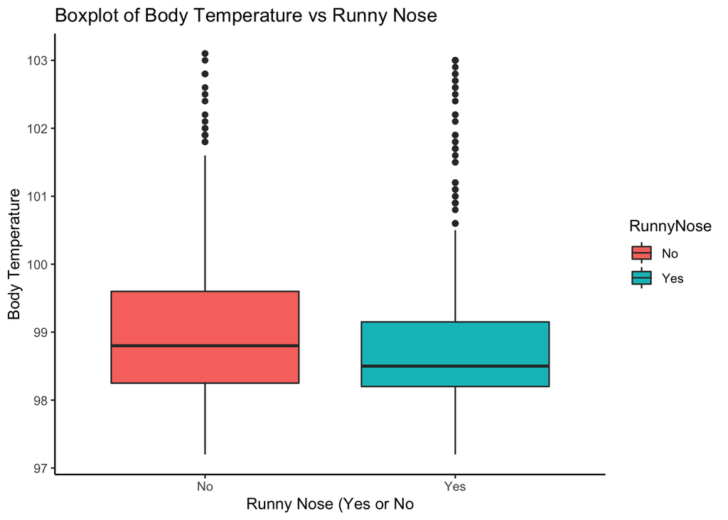

###Calculating Statistics on Body Temperature by Runny Nose Status

```r
#define quantiles of interest
q = c(.25, .75)

#calculate quantiles by grouping variable
table <- mydata %>%
  group_by(RunnyNose) %>%
  summarize(mean= round(mean(BodyTemp), 1) ,
            sd= round(sd(BodyTemp), 1),
            median = round(median(BodyTemp, na.rm=TRUE), 1),
            quant25 = round(quantile(BodyTemp, probs = q[1], na.rm=TRUE), 1),
            quant75 = round(quantile(BodyTemp, probs = q[2], na.rm= TRUE), 1))



#i also combine the 25th percentile and 75th into a character string seperated by a "-"
table$IQR <- paste(table$quant25, table$quant75, sep = "-")

#then i add parentheses around it using this function
addparentheses <- function(x){paste("(", x, ")")}
table$IQR <- addparentheses(table$IQR)


# we don't need the first row or middle colums so we delete them
table <- table[, -c(5,6)]

table
```

```
## # A tibble: 2 × 5
##   RunnyNose  mean    sd median IQR
##   <fct>     <dbl> <dbl>  <dbl> <chr>
## 1 No         99.1   1.3   98.8 ( 98.2-99.6 )
## 2 Yes        98.9   1.1   98.5 ( 98.2-99.2 )
```

```r
names(table)[1] <- "Runny Nose Status"


#saved it as a file
summarytable_file = here("results", "summarytable.rds")
saveRDS(table, file = summarytable_file)
```

Now I display the saved file for an improved aesthetic.

Table 1. Mean, Median, and IQR of Body Temperature by Runny Nose Status

| Runny Nose Status | mean | sd | median | IQR |
| --- | --- | --- | --- | --- |
| No | 99.1 | 1.3 | 98.8 | ( 98.2-99.6 ) |
| Yes | 98.9 | 1.1 | 98.5 | ( 98.2-99.2 ) |

### Plotting Swollen Lymph Nodes

Here we see that 312 (42.7%) of participants reported experiecing swollen lymph nodes.

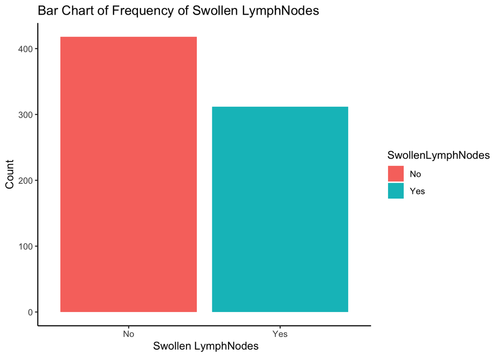

### Plotting Body Temperature by Swollen Lymph Nodes

Here we see that the median body temperature was fairly close between those who reported swollen lymph nodes and those who did not.

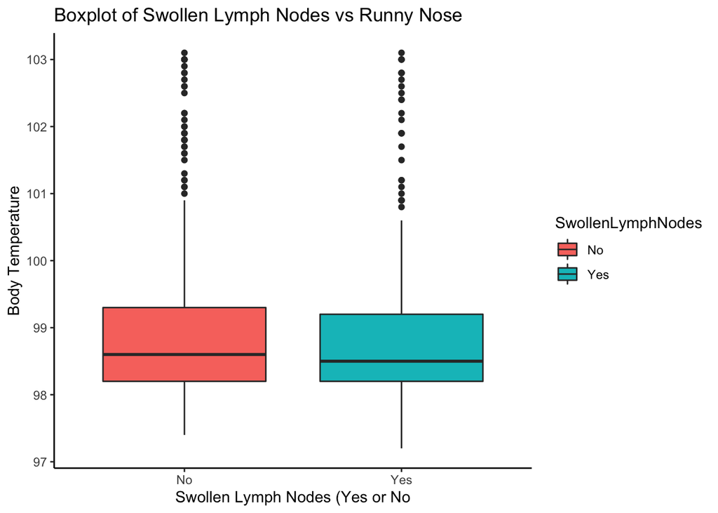

### Plotting Chest Congestion

Here we see that 407 (55.8%) of participants reported experiecing chest congestion.

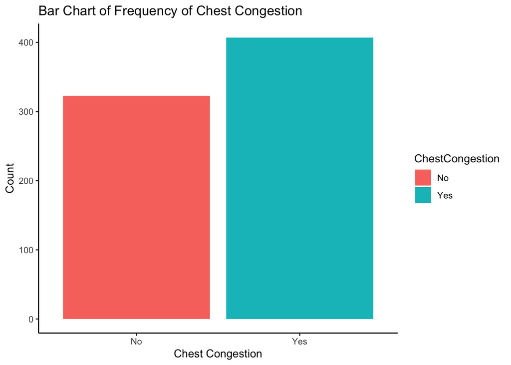

### Plotting Weakness Level

Here we see that 120 (16.4%) reported severe weakness, 338 (46.3%) reported moderate weakness, and 223 (30.5%) reported mild weakness.

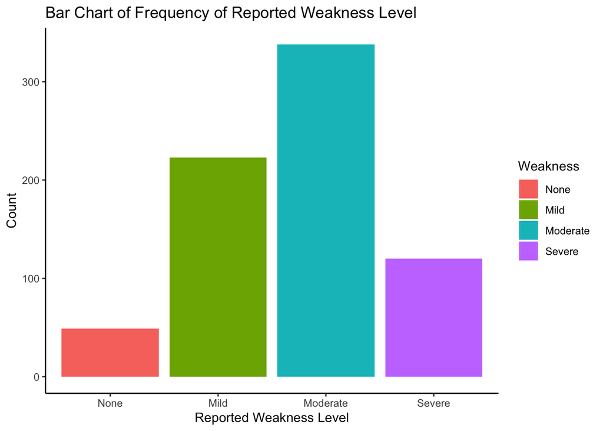